# Colby R Use Survey Results for 2018-2019

### Courses offering R and their registration counts

| Term | Course | Reg |
| --- | --- | --- |
| Fall | BI271 | 95 |
| Fall | BI278 | 12 |
| Fall | BI279 | 21 |
| Fall | BI332 | 3 |
| Fall | CS197 | 51 |
| Fall | ES214 | 24 |
| Fall | ES494 | 24 |
| Fall | SC212 | 128 |
| Fall | SC321 | 16 |
| Fall | SO264 | 4 |
| Janplan | ES214J | 21 |
| Janplan | JP297 | 19 |
| Spring | BI164 L | 176 |
| Spring | BI279 | 35 |
| Spring | BI382 | 11 |
| Spring | ES218 | 15 |
| Spring | ES319 | 14 |
| Spring | ES338 | 12 |
| Spring | SC212 | 103 |
| Spring | SC321 | 22 |
| Spring | SC398 | 10 |
| Spring | SC482 | 16 |
| Spring | SO271 | 19 |

### Course block distribution for R themed courses

Box width is proportional to the number of registered students. Equal transparency is applied to each course block.

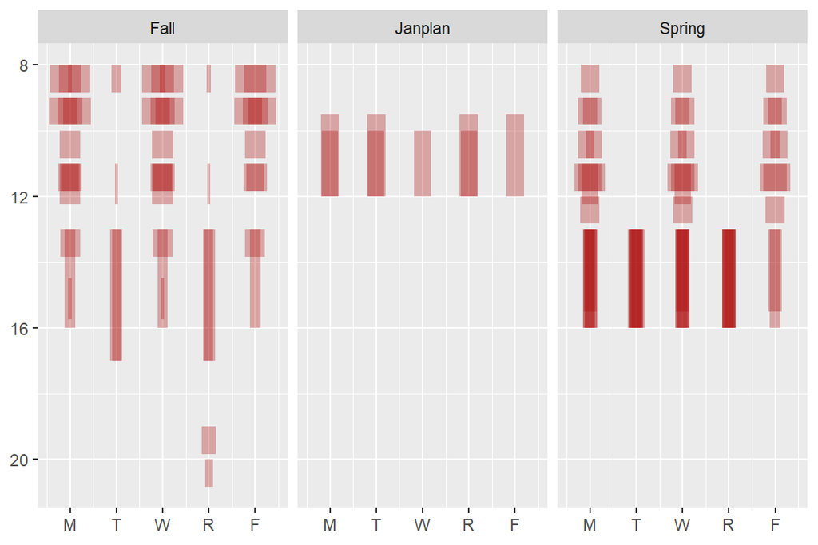

### Course block distribution for R themed courses by R usage type

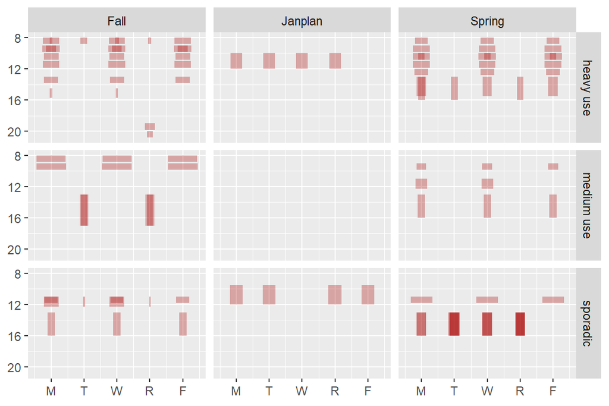

### Mosaic plot of student count by R use exposure and term

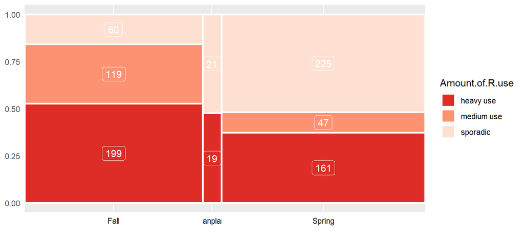

### Mosaic plot of student count by department

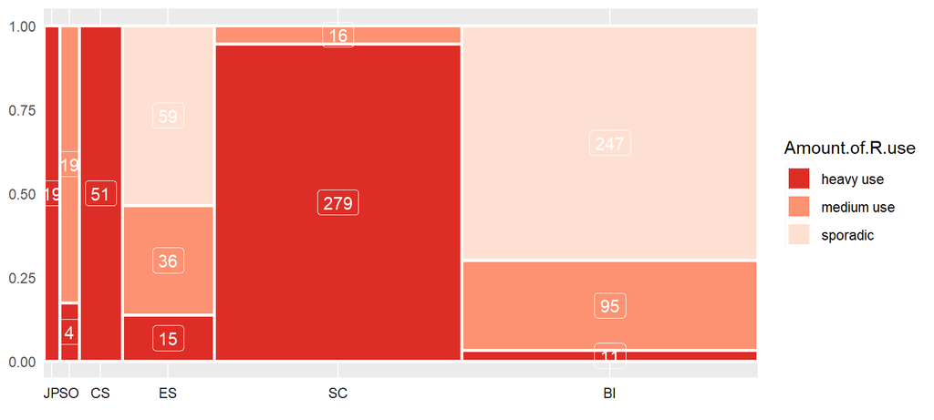

### Other R course survey summaries (with student count)

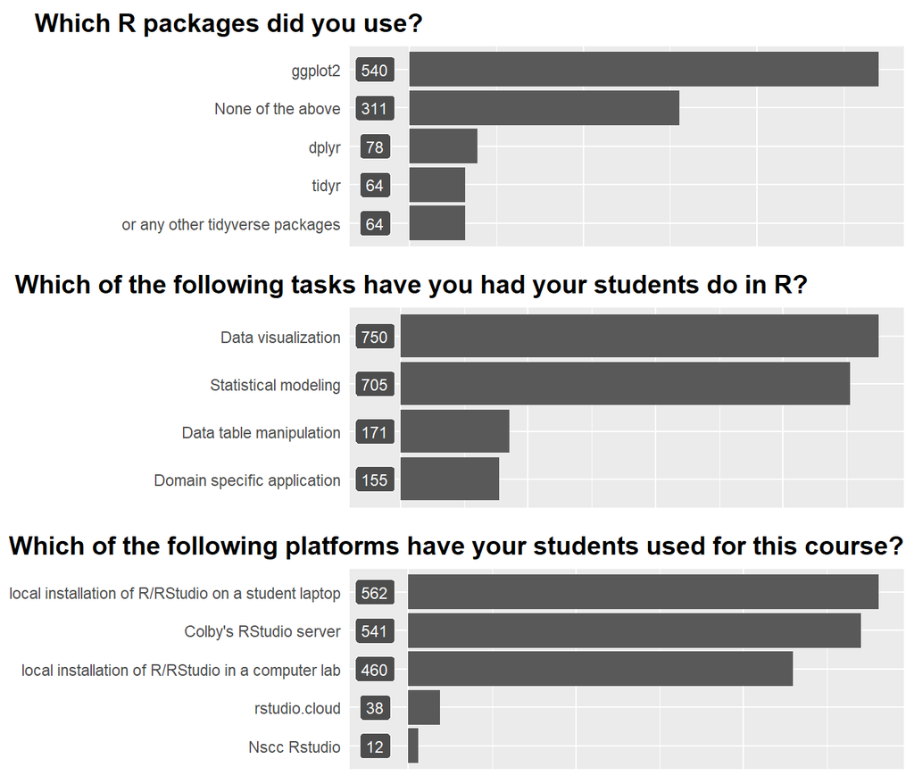

### Number of unique students exposed to R this year

Each bar represents the total number of students exposed to one or more R themed courses. For example, the first bar on the left shows that 444 students were exposed to just one course with an R component this academic year. The bar to the far right (which is barely discernible) shows that 4 students were exposed to four courses with an R component this academic year. A total of **611** unique students were exposed to R in at least one course this academic year.

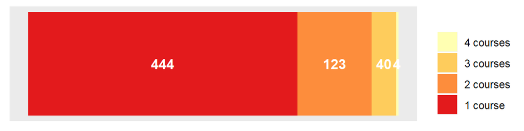

### Chord diagram

This next plot attempts to map the student “flow” between R themed courses. You can hover over the different elements in the plot to extract the student count. For example, hovering over the largest chord linking SC212 to BI217 indicates that 41 students took both SC212 and BI271 this academic year.

The recursive chords (chords that link a course to itself) shows the *approximate* number of students in that course that have not been exposed to any other course in the circle. For example, the bubble for SC212 shows that 97 students may not have taken another R themed course.

> Note that the recursive chord number may be under-inflated as a result of the way the matrix feeding into the chord diagram was created. Some students may have been exposed to more than two courses which would result in an extra “student” unit being removed from the recursive chord. This double-counting of students can also manifest itself in the student total count value shown when hovering the cursor over the course’s arc length. For example, ES218 shows 18 registered students when the total count is in fact 15. The three extra students were added to the total as a result of three (or fewer) students having been exposed to *two* (or more) other R-themed courses. Note that this double accounting of the total course count should only manifest itself for those courses where the sum of cross-referenced students is greater than the total number of students registered for the course.

Despite the potential accounting issues associated with the bubble and total course counts, the chord counts (chords linking courses) are correct and do not reflect the aforementioned bias.

[interactive chart not shown]